# goodman_assignment05

### Problem

It is seen in nature that species can coexist with each other in various circumstances, even among those that have a naturally antagonistic relationship. The means by which this biodiversity is maintained is unclear, as one would assume that competition among the species, especially in communities with antagonistic species, would result in the elimination of susceptible species.

The study published in Nature addresses the effect of inter-species competition on biodiversity, using a rock-paper-scissors model to simulate a community of three competing species. The nature of the simulation is to account for interaction and dispersal of the species over time in both a localized and large-scale population to determine the resulting effects on each species’ survival.

### Assumptions

We assume that in the simulated community of three species, the S strain always displaces the R strain, R always displaces C, and C can only displace S if its local population around a colony of S is large enough. It is also assumed that each unpopulated point in the matrix has a chance to remain unpopulated after a simulation equal to the chance of it being populated by one of the strains. Finally, the populations are assumed to be equal in the beginning and each strain’s characteristics remain unchanged over the course of multiple generations (i.e., there are no mutations or other changes that would affect the interaction/dispersal patterns of a species).

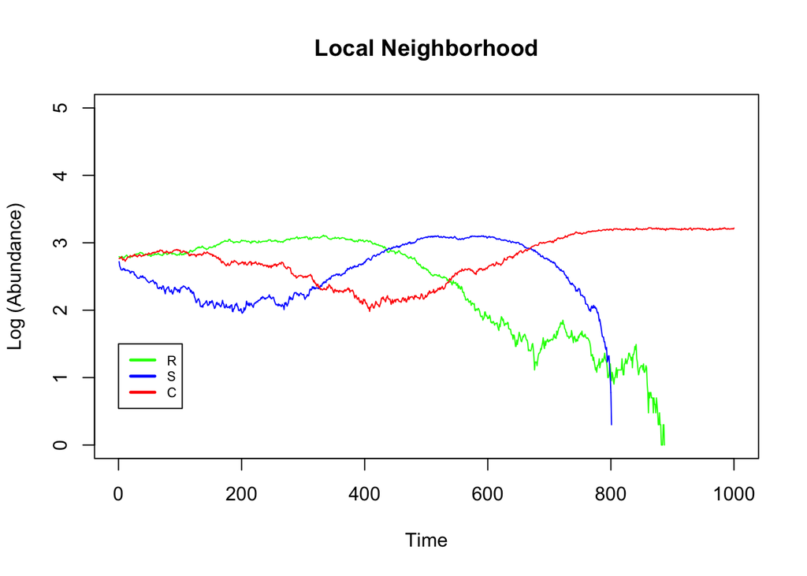

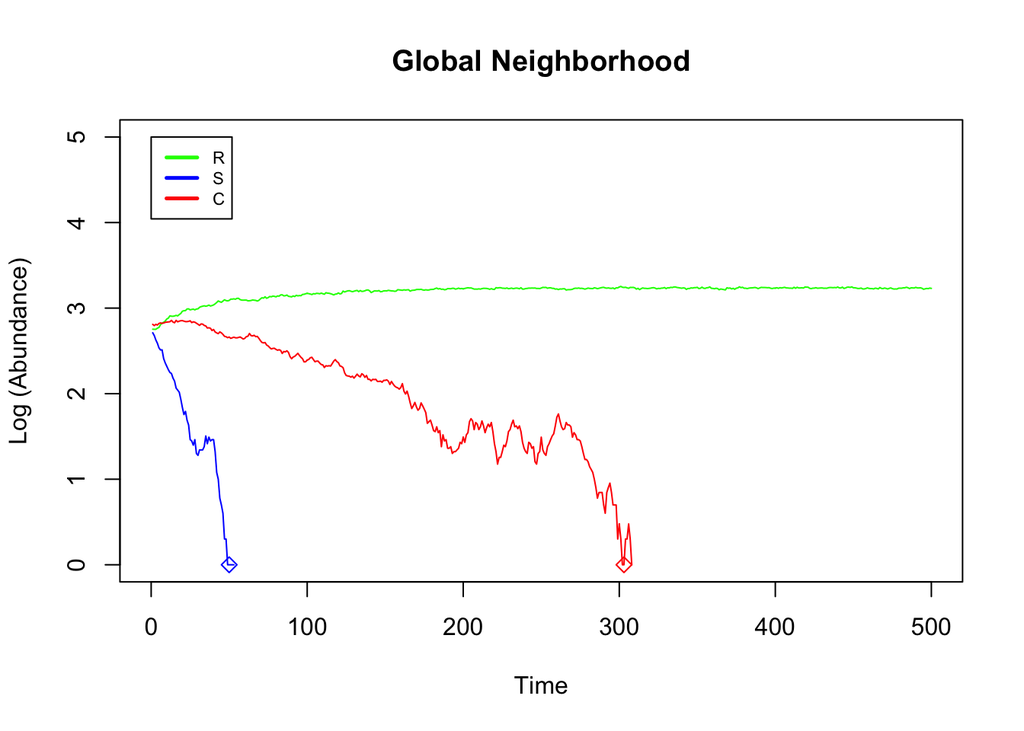

### Experiment:

The initial matrix generated from imitating the Nature paper assumes a random distribution of all four species will populate the cells. Over time, the rock-paper-scissors hierarchy results in the decline in the number of the susceptible species in the global population until it is totally out-competed by the other species. We hypothesize that if the “S” species has an advantage to begin with, it will not die off as quickly in the global environment. In order to test this, we can manipulate the random distribution of species within the initial matrix to preferentially choose “S” with a probability of 50%. Doing this ensures that about half of the cells in the matrix will be filled with the susceptible species.

Running the global simulation under these conditions shows that the abundance of “S” may initially decline, but quickly recovers and totally out competes the other two species. If there are significantly more “S” bacteria than “R” and “C” to begin with, “S” will not die out of the global population.

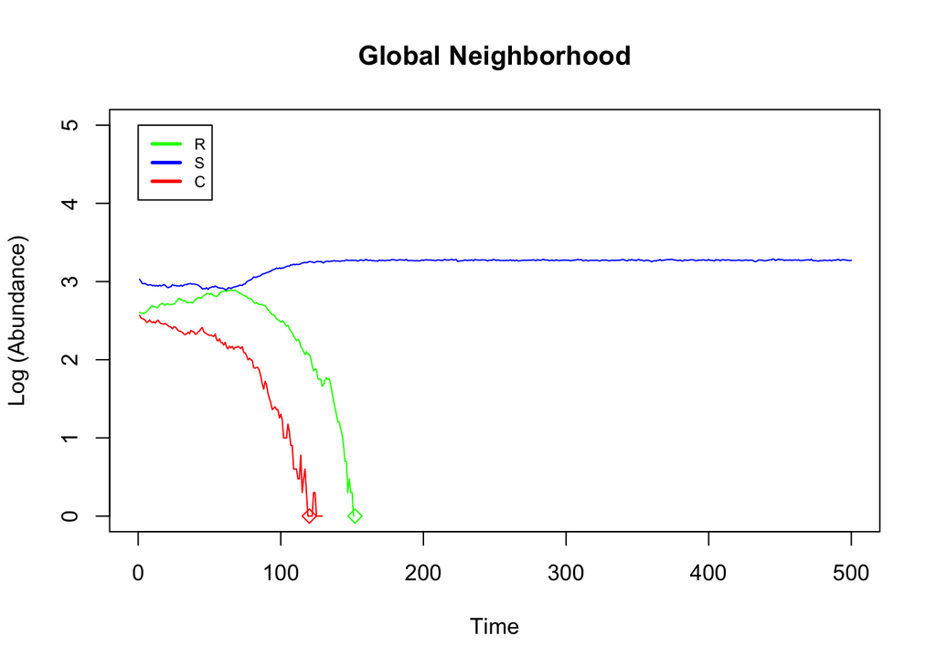